# final EFA Practice

Author

firdaus

This analysis is for Practice section, with selection threshold higher (FL =>0.5), communality => 0.5

# 1 Preliminaries

## 1.1 Load libraries

```r
library(foreign)  # for importing SPSS data
library(psych)  # for psychometrics
library(lattice)  # easy to plot multivariate plots
library(readxl)
library(dplyr)
```

## 1.2 Load dataset

```r
data1= read_xlsx("EFA_Practice_V1.xlsx")
```

```r
names(data1)
```

```
 [1] "P1"  "P2"  "P3"  "P4"  "P5"  "P6"  "P7"  "P8"  "P9"  "P10" "P11" "P12"
[13] "P13" "P14" "P15" "P16" "P17" "P18" "P19" "P20" "P21" "P22" "P23" "P24"
[25] "P25" "P26" "P27" "P28"
```

```r
head(data1)
```

```
# A tibble: 6 × 28
  P1     P2    P3    P4    P5    P6    P7    P8    P9    P10   P11   P12   P13
  <chr>  <chr> <chr> <chr> <chr> <chr> <chr> <chr> <chr> <chr> <chr> <chr> <chr>
1 Tidak… Sent… Sent… Tida… Tida… Sent… Sent… Tida… Sent… Kada… Sent… Sent… Sent…
2 Tidak… Sent… Sent… Tida… Sent… Sent… Sent… Tida… Sent… Kada… Kada… Kada… Sent…
3 Kadan… Sent… Sent… Tida… Sent… Sent… Sent… Sent… Sent… Sela… Kada… Sela… Sent…
4 Kadan… Sela… Sela… Sela… Sela… Sela… Sela… Kada… Kada… Sela… Sela… Sela… Sela…
5 Kadan… Sent… Sent… Tida… Sent… Sent… Sent… Sent… Sent… Sent… Sela… Sent… Sela…
6 Senti… Sent… Sent… Tida… Sent… Sent… Sent… Sent… Sent… Sent… Kada… Sela… Sent…
# ℹ 15 more variables: P14 <chr>, P15 <chr>, P16 <chr>, P17 <chr>, P18 <chr>,
#   P19 <chr>, P20 <chr>, P21 <chr>, P22 <chr>, P23 <chr>, P24 <chr>,
#   P25 <chr>, P26 <chr>, P27 <chr>, P28 <chr>
```

## 1.3 Coding the answers

```r
# Define mapping function
likert_map <- function(x) {
  recode <- c(
    "Tidak pernah" = 1,
    "Jarang"        = 2,
    "Kadang-kadang"         = 3,
    "Selalu"              = 4,
    "Sentiasa"       = 5
  )
  recode[match(tolower(x), tolower(names(recode)))]
}

# Apply transformation from data1 -> data2
data2 <- data1

for (col in names(data2)) {
  data2[[col]] <- likert_map(data2[[col]])
}

# Convert all to numeric
data2 <- as.data.frame(lapply(data2, as.numeric))
```

```r
head(data2)
```

```
  P1 P2 P3 P4 P5 P6 P7 P8 P9 P10 P11 P12 P13 P14 P15 P16 P17 P18 P19 P20 P21
1  1  5  5  1  1  5  5  1  5   3   5   5   5   5   5   5   1   5   5   5   5
2  1  5  5  1  5  5  5  1  5   3   3   3   5   5   5   5   5   5   5   5   5
3  3  5  5  1  5  5  5  5  5   4   3   4   5   5   5   5   5   5   5   5   5
4  3  4  4  4  4  4  4  3  3   4   4   4   4   4   4   4   4   4   4   4   4
5  3  5  5  1  5  5  5  5  5   5   4   5   4   5   5   5   5   5   5   3   5
6  5  5  5  1  5  5  5  5  5   5   3   4   5   5   5   5   5   5   5   5   5
  P22 P23 P24 P25 P26 P27 P28
1   5   5   5   5   5   5   5
2   5   5   5   5   5   5   5
3   5   5   3   4   3   5   5
4   4   4   4   4   3   4   4
5   5   5   3   5   5   5   5
6   5   5   3   4   5   4   4
```

```r
str(data2)
```

```
'data.frame':   204 obs. of  28 variables:
 $ P1 : num  1 1 3 3 3 5 3 5 1 3 ...
 $ P2 : num  5 5 5 4 5 5 5 5 5 4 ...
 $ P3 : num  5 5 5 4 5 5 5 5 5 5 ...
 $ P4 : num  1 1 1 4 1 1 1 5 1 5 ...
 $ P5 : num  1 5 5 4 5 5 5 5 3 5 ...
 $ P6 : num  5 5 5 4 5 5 5 5 3 5 ...
 $ P7 : num  5 5 5 4 5 5 5 5 1 5 ...
 $ P8 : num  1 1 5 3 5 5 5 5 1 3 ...
 $ P9 : num  5 5 5 3 5 5 5 5 5 3 ...
 $ P10: num  3 3 4 4 5 5 5 5 5 3 ...
 $ P11: num  5 3 3 4 4 3 4 4 3 3 ...
 $ P12: num  5 3 4 4 5 4 4 5 4 4 ...
 $ P13: num  5 5 5 4 4 5 5 5 5 3 ...
 $ P14: num  5 5 5 4 5 5 5 5 5 3 ...
 $ P15: num  5 5 5 4 5 5 5 5 5 3 ...
 $ P16: num  5 5 5 4 5 5 5 5 5 3 ...
 $ P17: num  1 5 5 4 5 5 5 5 5 4 ...
 $ P18: num  5 5 5 4 5 5 4 5 5 3 ...
 $ P19: num  5 5 5 4 5 5 4 5 5 4 ...
 $ P20: num  5 5 5 4 3 5 5 5 5 3 ...
 $ P21: num  5 5 5 4 5 5 4 5 5 3 ...
 $ P22: num  5 5 5 4 5 5 5 5 3 2 ...
 $ P23: num  5 5 5 4 5 5 5 5 5 4 ...
 $ P24: num  5 5 3 4 3 3 5 3 5 4 ...
 $ P25: num  5 5 4 4 5 4 5 3 3 3 ...
 $ P26: num  5 5 3 3 5 5 5 3 3 4 ...
 $ P27: num  5 5 5 4 5 4 5 4 5 4 ...
 $ P28: num  5 5 5 4 5 4 5 4 5 4 ...
```

# 2 Exploratory factor analysis

## 2.1 Descriptive statistics

```r
describe(data2)
```

```
    vars   n mean   sd median trimmed  mad min max range  skew kurtosis   se
P1     1 204 2.55 1.42      3    2.44 1.48   1   5     4  0.28    -1.30 0.10
P2     2 204 4.36 0.75      4    4.48 1.48   1   5     4 -1.39     2.59 0.05
P3     3 204 4.38 0.70      4    4.48 1.48   1   5     4 -1.19     2.29 0.05
P4     4 204 2.15 1.59      1    1.95 0.00   1   5     4  0.80    -1.14 0.11
P5     5 204 3.87 1.15      4    4.06 1.48   1   5     4 -1.13     0.63 0.08
P6     6 204 3.96 1.17      4    4.16 1.48   1   5     4 -1.26     0.86 0.08
P7     7 204 3.90 1.21      4    4.10 1.48   1   5     4 -1.15     0.45 0.08
P8     8 204 3.41 1.43      4    3.51 1.48   1   5     4 -0.56    -1.03 0.10
P9     9 204 3.85 1.24      4    4.04 1.48   1   5     4 -1.04     0.09 0.09
P10   10 204 3.48 1.26      4    3.59 1.48   1   5     4 -0.63    -0.53 0.09
P11   11 204 2.94 1.27      3    2.92 1.48   1   5     4 -0.12    -1.00 0.09
P12   12 204 3.42 1.22      4    3.52 1.48   1   5     4 -0.57    -0.54 0.09
P13   13 204 4.10 1.02      4    4.27 1.48   1   5     4 -1.23     1.19 0.07
P14   14 204 3.82 1.35      4    4.02 1.48   1   5     4 -1.04    -0.17 0.09
P15   15 204 3.83 1.37      4    4.04 1.48   1   5     4 -1.09    -0.11 0.10
P16   16 204 4.15 1.08      4    4.35 1.48   1   5     4 -1.37     1.31 0.08
P17   17 204 3.53 1.64      4    3.66 1.48   1   5     4 -0.66    -1.26 0.11
P18   18 204 4.05 1.13      4    4.28 1.48   1   5     4 -1.44     1.49 0.08
P19   19 204 4.26 0.99      5    4.46 0.00   1   5     4 -1.60     2.34 0.07
P20   20 204 4.18 1.08      5    4.38 0.00   1   5     4 -1.44     1.53 0.08
P21   21 204 3.69 1.33      4    3.86 1.48   1   5     4 -0.76    -0.61 0.09
P22   22 204 3.78 1.32      4    3.98 1.48   1   5     4 -0.96    -0.24 0.09
P23   23 204 4.07 1.14      4    4.29 1.48   1   5     4 -1.36     1.10 0.08
P24   24 204 3.91 1.10      4    4.07 1.48   1   5     4 -0.98     0.35 0.08
P25   25 204 3.50 1.29      4    3.63 1.48   1   5     4 -0.61    -0.69 0.09
P26   26 204 3.64 1.23      4    3.79 1.48   1   5     4 -0.75    -0.37 0.09
P27   27 204 3.69 1.24      4    3.84 1.48   1   5     4 -0.73    -0.41 0.09
P28   28 204 3.58 1.31      4    3.72 1.48   1   5     4 -0.66    -0.73 0.09
```

## 2.2 % of response to options per item

```r
response.frequencies(data2)
```

```
              1           2          3         4         5 miss
P1  0.362745098 0.127450980 0.21568627 0.1862745 0.1078431    0
P2  0.004901961 0.029411765 0.04901961 0.4313725 0.4852941    0
P3  0.004901961 0.009803922 0.06862745 0.4313725 0.4852941    0
P4  0.627450980 0.029411765 0.04411765 0.1617647 0.1372549    0
P5  0.078431373 0.039215686 0.14705882 0.4019608 0.3333333    0
P6  0.078431373 0.044117647 0.09803922 0.4019608 0.3774510    0
P7  0.088235294 0.049019608 0.11274510 0.3774510 0.3725490    0
P8  0.186274510 0.073529412 0.15686275 0.3137255 0.2696078    0
P9  0.088235294 0.068627451 0.11764706 0.3578431 0.3676471    0
P10 0.122549020 0.068627451 0.24509804 0.3382353 0.2254902    0
P11 0.196078431 0.137254902 0.31372549 0.2401961 0.1127451    0
P12 0.112745098 0.088235294 0.25980392 0.3431373 0.1960784    0
P13 0.034313725 0.044117647 0.13235294 0.3627451 0.4264706    0
P14 0.122549020 0.063725490 0.07843137 0.3382353 0.3970588    0
P15 0.137254902 0.044117647 0.07352941 0.3382353 0.4068627    0
P16 0.044117647 0.049019608 0.10294118 0.3235294 0.4803922    0
P17 0.254901961 0.029411765 0.06372549 0.2303922 0.4215686    0
P18 0.073529412 0.024509804 0.09313725 0.3921569 0.4166667    0
P19 0.034313725 0.034313725 0.08333333 0.3284314 0.5196078    0
P20 0.049019608 0.034313725 0.11274510 0.2990196 0.5049020    0
P21 0.107843137 0.093137255 0.15686275 0.2843137 0.3578431    0
P22 0.112745098 0.068627451 0.11274510 0.3333333 0.3725490    0
P23 0.063725490 0.049019608 0.08823529 0.3480392 0.4509804    0
P24 0.049019608 0.063725490 0.17156863 0.3627451 0.3529412    0
P25 0.117647059 0.098039216 0.20098039 0.3284314 0.2549020    0
P26 0.093137255 0.083333333 0.19607843 0.3480392 0.2794118    0
P27 0.083333333 0.088235294 0.20098039 0.3137255 0.3137255    0
P28 0.107843137 0.122549020 0.14215686 0.3382353 0.2892157    0
```

## 2.3 Normality of data

### 2.3.1 Univariate normality

#### 2.3.1.1 Histogram

```r
cat(names(data2), sep = " + ")
```

```
P1 + P2 + P3 + P4 + P5 + P6 + P7 + P8 + P9 + P10 + P11 + P12 + P13 + P14 + P15 + P16 + P17 + P18 + P19 + P20 + P21 + P22 + P23 + P24 + P25 + P26 + P27 + P28
```

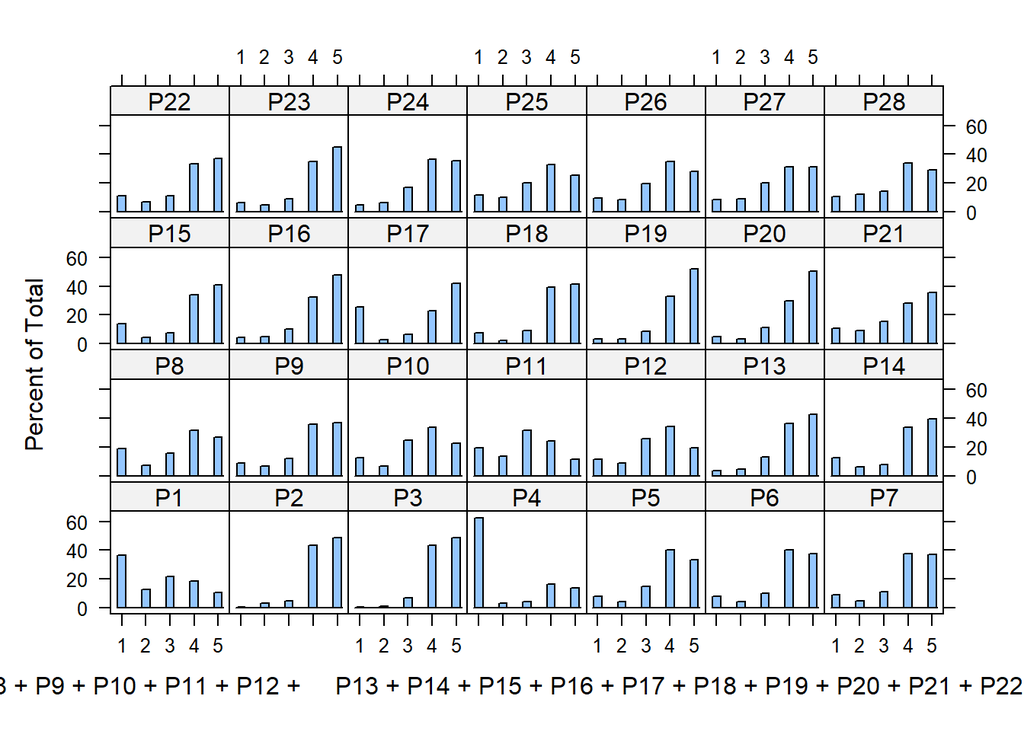

```r
histogram(~ P1 + P2 + P3 + P4 + P5 + P6 + P7 + P8 + P9 + P10 + P11 + P12 + P13 + P14 + P15 + P16 + P17 + P18 + P19 + P20 + P21 + P22 + P23 + P24 + P25 + P26 + P27 + P28, data = data2)
```

#### 2.3.1.2 Shapiro Wilk’s test

```r
mapply(shapiro.test, data2)
```

```
          P1                            P2
statistic 0.852815                      0.7314472
p.value   4.200133e-13                  6.741398e-18
method    "Shapiro-Wilk normality test" "Shapiro-Wilk normality test"
data.name "dots[[1L]][[1L]]"            "dots[[1L]][[2L]]"
          P3                            P4
statistic 0.7427625                     0.6807799
p.value   1.58217e-17                   1.989631e-19
method    "Shapiro-Wilk normality test" "Shapiro-Wilk normality test"
data.name "dots[[1L]][[3L]]"            "dots[[1L]][[4L]]"
          P5                            P6
statistic 0.8064811                     0.7760312
p.value   3.491198e-15                  2.304898e-16
method    "Shapiro-Wilk normality test" "Shapiro-Wilk normality test"
data.name "dots[[1L]][[5L]]"            "dots[[1L]][[6L]]"
          P7                            P8
statistic 0.7897049                     0.8424545
p.value   7.540785e-16                  1.324524e-13
method    "Shapiro-Wilk normality test" "Shapiro-Wilk normality test"
data.name "dots[[1L]][[7L]]"            "dots[[1L]][[8L]]"
          P9                            P10
statistic 0.8050194                     0.8692087
p.value   3.043557e-15                  2.940812e-12
method    "Shapiro-Wilk normality test" "Shapiro-Wilk normality test"
data.name "dots[[1L]][[9L]]"            "dots[[1L]][[10L]]"
          P11                           P12
statistic 0.8994439                     0.881362
p.value   1.725655e-10                  1.389132e-11
method    "Shapiro-Wilk normality test" "Shapiro-Wilk normality test"
data.name "dots[[1L]][[11L]]"           "dots[[1L]][[12L]]"
          P13                           P14
statistic 0.7896731                     0.7775584
p.value   7.519535e-16                  2.624201e-16
method    "Shapiro-Wilk normality test" "Shapiro-Wilk normality test"
data.name "dots[[1L]][[13L]]"           "dots[[1L]][[14L]]"
          P15                           P16
statistic 0.7621649                     0.7567492
p.value   7.301049e-17                  4.722167e-17
method    "Shapiro-Wilk normality test" "Shapiro-Wilk normality test"
data.name "dots[[1L]][[15L]]"           "dots[[1L]][[16L]]"
```

[output cut: 15 more lines]

```
          P23                           P24
statistic 0.7561697                     0.8307433
p.value   4.508904e-17                  3.823045e-14
method    "Shapiro-Wilk normality test" "Shapiro-Wilk normality test"
data.name "dots[[1L]][[23L]]"           "dots[[1L]][[24L]]"
          P25                           P26
statistic 0.8679813                     0.8577885
p.value   2.527929e-12                  7.456844e-13
method    "Shapiro-Wilk normality test" "Shapiro-Wilk normality test"
data.name "dots[[1L]][[25L]]"           "dots[[1L]][[26L]]"
          P27                           P28
statistic 0.8564256                     0.8530448
p.value   6.362859e-13                  4.311746e-13
method    "Shapiro-Wilk normality test" "Shapiro-Wilk normality test"
data.name "dots[[1L]][[27L]]"           "dots[[1L]][[28L]]"
```

#### 2.3.1.3 Multivariate normality

To say the data are multivariate normal:

- *z*-kurtosis < 5 ([Bentler, 2006](https://wnarifin.github.io/lecture/mstat/efa_medstat_practical.html#ref-bentler2006)) and the *P*-value should be ≥ 0.05
- The plot should also form a straight line ([Arifin, 2015](https://wnarifin.github.io/lecture/mstat/efa_medstat_practical.html#ref-arifin2015))

Run Mardia’s multivariate normality test,

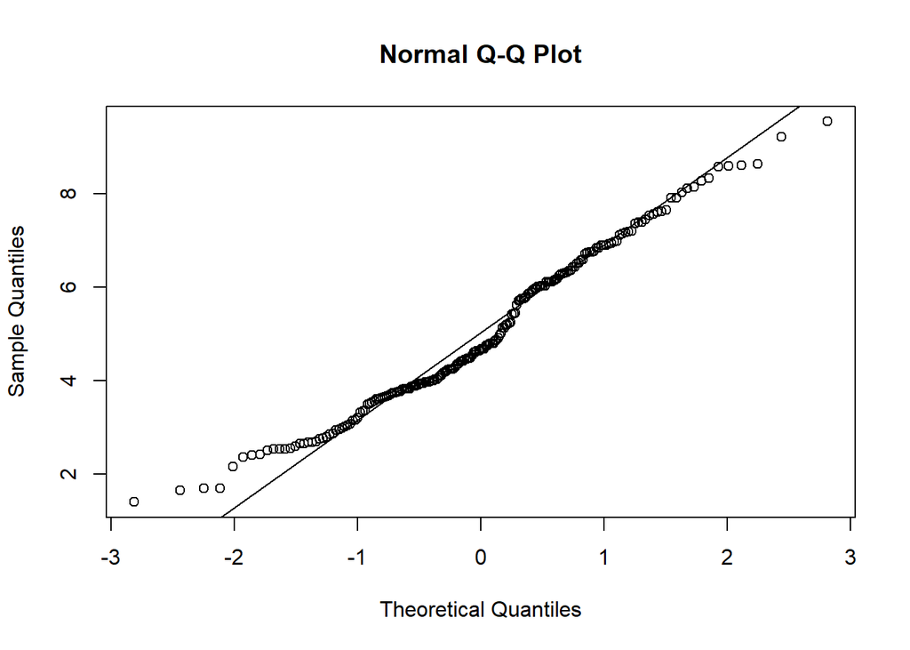

```
Call: mardia(x = data2)

Mardia tests of multivariate skew and kurtosis
Use describe(x) the to get univariate tests
n.obs = 204   num.vars =  28
b1p =  304.71   skew =  10360.21  with probability  <=  0
 small sample skew =  10523.19  with probability <=  0
b2p =  1116.7   kurtosis =  48.21  with probability <=  0
```

```r
mardia(data2)
```

## 2.4 Step 1

### 2.4.1 Check suitability of data for analysis

#### 2.4.1.1 Kaiser-Meyer-Olkin (KMO) Measure of Sampling Adequacy (MSA)

```r
KMO(data2)
```

```
Kaiser-Meyer-Olkin factor adequacy
Call: KMO(r = data2)
Overall MSA =  0.91
MSA for each item =
  P1   P2   P3   P4   P5   P6   P7   P8   P9  P10  P11  P12  P13  P14  P15  P16
0.90 0.87 0.89 0.88 0.91 0.91 0.94 0.93 0.96 0.95 0.90 0.92 0.93 0.85 0.86 0.91
 P17  P18  P19  P20  P21  P22  P23  P24  P25  P26  P27  P28
0.94 0.90 0.92 0.95 0.91 0.93 0.91 0.89 0.93 0.91 0.89 0.91
```

#### 2.4.1.2 Bartlet’s test of sphericity

```r
cortest.bartlett(data2)
```

```
R was not square, finding R from data
```

```
$chisq
[1] 4869.189

$p.value
[1] 0

$df
[1] 378
```

### 2.4.2 Determine the number of factors

#### 2.4.2.1 Eigen value & scree plot

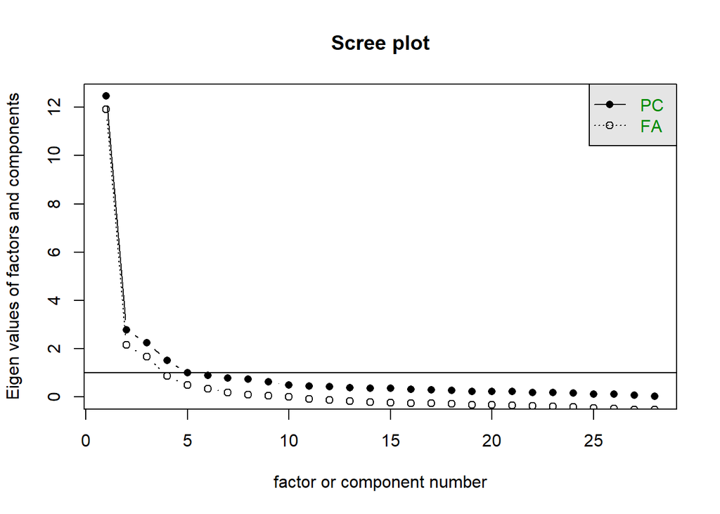

```r
scree = scree(data2)
```

```r
print(scree)
```

```
Scree of eigen values
Call: NULL
Eigen values of factors  [1] 11.93  2.15  1.66  0.88  0.48  0.33  0.19  0.10  0.04  0.00 -0.08 -0.14
[13] -0.18 -0.22 -0.25 -0.26 -0.27 -0.29 -0.32 -0.33 -0.35 -0.36 -0.40 -0.41
[25] -0.46 -0.48 -0.52 -0.54
Eigen values of Principal Components [1] 12.46  2.78  2.25  1.52  1.01  0.90  0.79  0.74  0.63  0.49  0.46  0.42
[13]  0.38  0.37  0.35  0.32  0.29  0.28  0.24  0.22  0.22  0.19  0.19  0.15
[25]  0.12  0.12  0.07  0.03
```

#### 2.4.2.2 Parallel analysis

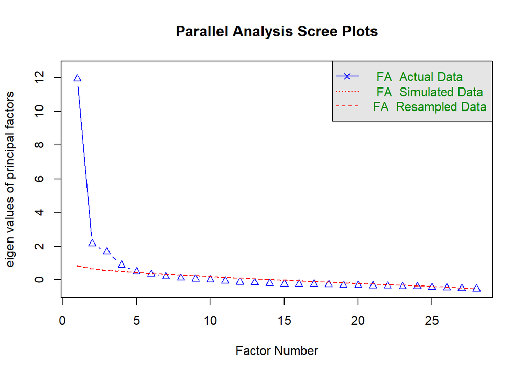

```
Parallel analysis suggests that the number of factors =  4  and the number of components =  NA
```

```r
parallel = fa.parallel(data2, fm = "pa", fa = "fa")
```

#### 2.4.2.3 Very simple structure (VSS) criterion & Velicer’s minimum average partial (MAP) criterion)

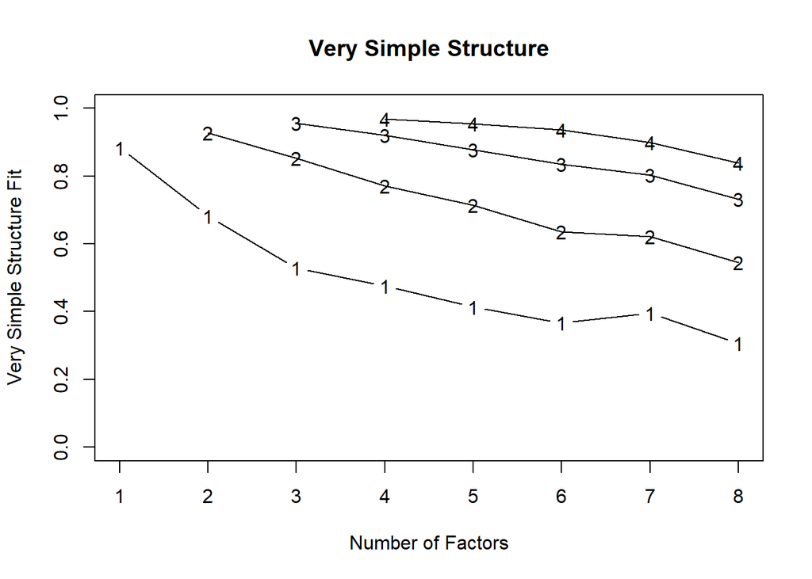

```
Very Simple Structure
Call: vss(x = data2)
VSS complexity 1 achieves a maximimum of 0.88  with  1  factors
VSS complexity 2 achieves a maximimum of 0.93  with  2  factors

The Velicer MAP achieves a minimum of 0.02  with  5  factors
BIC achieves a minimum of  -601.52  with  6  factors
Sample Size adjusted BIC achieves a minimum of  37.55  with  8  factors

Statistics by number of factors
  vss1 vss2   map dof chisq     prob sqresid  fit RMSEA  BIC SABIC complex
1 0.88 0.00 0.047 350  2332 2.8e-289    20.4 0.88 0.167  471  1580     1.0
2 0.68 0.93 0.039 323  1656 1.4e-177    12.8 0.93 0.142  -62   961     1.3
3 0.53 0.85 0.028 297  1217 1.6e-111     7.8 0.96 0.123 -363   578     1.6
4 0.48 0.77 0.025 272   943  8.2e-75     5.6 0.97 0.110 -504   358     1.8
5 0.41 0.71 0.025 248   770  7.8e-55     4.7 0.97 0.101 -549   237     2.1
6 0.37 0.64 0.025 225   595  3.3e-35     3.9 0.98 0.090 -602   111     2.3
7 0.40 0.62 0.027 203   491  6.0e-26     3.4 0.98 0.083 -588    55     2.4
8 0.31 0.54 0.028 182   429  5.7e-22     2.8 0.98 0.081 -539    38     2.6
  eChisq  SRMR eCRMS  eBIC
1   2185 0.119 0.124   323
2   1129 0.086 0.093  -589
3    492 0.056 0.064 -1087
4    272 0.042 0.050 -1175
5    185 0.035 0.043 -1134
6    123 0.028 0.037 -1074
7     87 0.024 0.032  -992
8     59 0.020 0.028  -909
```

```r
vss(data2)
```

## 2.5 Step 2

### 2.5.1 Run EFA 5 factors

Cut off factor loading based on Hair (2019) ( => 0.5 practically significant structure)

```r
fa = fa(data2, nfactors = 5, fm = "pa", rotate = "oblimin")
print(fa, cut = .5, digits = 3)  # cut = .3 to view only FLs > 0.3
```

```
Factor Analysis using method =  pa
Call: fa(r = data2, nfactors = 5, rotate = "oblimin", fm = "pa")
Standardized loadings (pattern matrix) based upon correlation matrix
       PA2    PA3    PA5    PA4    PA1    h2     u2  com
P1                               0.598 0.496 0.5043 1.14
P2                        0.752        0.556 0.4439 1.00
P3                        0.868        0.800 0.1999 1.05
P4                               0.584 0.387 0.6126 1.42
P5                                     0.736 0.2639 2.75
P6                                     0.760 0.2404 2.97
P7                                     0.700 0.3000 3.20
P8                                     0.669 0.3310 2.46
P9                                     0.631 0.3686 2.87
P10                              0.514 0.663 0.3375 1.85
P11                              0.545 0.529 0.4710 1.59
P12                              0.516 0.653 0.3475 2.02
P13  0.776                             0.634 0.3656 1.14
P14  0.964                             0.909 0.0913 1.03
P15  0.937                             0.896 0.1039 1.03
P16  0.878                             0.753 0.2470 1.08
P17  0.685                             0.581 0.4190 1.18
P18                                    0.664 0.3361 2.93
P19                                    0.712 0.2883 4.12
P20                0.520               0.614 0.3864 2.11
P21                0.786               0.754 0.2462 1.13
P22                0.770               0.791 0.2091 1.12
P23                                    0.413 0.5874 1.92
P24         0.575                      0.491 0.5089 1.27
P25         0.827                      0.699 0.3013 1.11
P26         0.761                      0.639 0.3605 1.07
P27         0.766                      0.685 0.3154 1.05
P28         0.665                      0.561 0.4390 1.17

                        PA2   PA3   PA5   PA4   PA1
SS loadings           4.624 3.953 3.571 3.200 3.026
Proportion Var        0.165 0.141 0.128 0.114 0.108
Cumulative Var        0.165 0.306 0.434 0.548 0.656
Proportion Explained  0.252 0.215 0.194 0.174 0.165
Cumulative Proportion 0.252 0.467 0.661 0.835 1.000

```

[output cut: 14 more lines]

```
The root mean square of the residuals (RMSR) is  0.035
The df corrected root mean square of the residuals is  0.043

The harmonic n.obs is  204 with the empirical chi square  185.269  with prob <  0.999
The total n.obs was  204  with Likelihood Chi Square =  769.489  with prob <  9.24e-55

Tucker Lewis Index of factoring reliability =  0.8196
RMSEA index =  0.1014  and the 90 % confidence intervals are  0.0937 0.11
BIC =  -549.405
Fit based upon off diagonal values = 0.994
Measures of factor score adequacy
                                                    PA2   PA3   PA5   PA4   PA1
Correlation of (regression) scores with factors   0.981 0.950 0.950 0.948 0.929
Multiple R square of scores with factors          0.963 0.902 0.903 0.899 0.862
Minimum correlation of possible factor scores     0.926 0.804 0.806 0.798 0.725
```

### 2.5.2 Run EFA 4 factors

```r
fa = fa(data2, nfactors = 4, fm = "pa", rotate = "oblimin")
print(fa, cut = .5, digits = 3)  # cut = .3 to view only FLs > 0.3
```

```
Factor Analysis using method =  pa
Call: fa(r = data2, nfactors = 4, rotate = "oblimin", fm = "pa")
Standardized loadings (pattern matrix) based upon correlation matrix
       PA1    PA3    PA2    PA4    h2     u2  com
P1   0.773                      0.498 0.5015 1.07
P2                        0.632 0.536 0.4644 1.22
P3                        0.710 0.745 0.2548 1.28
P4   0.621                      0.364 0.6364 1.46
P5   0.652                      0.734 0.2657 1.49
P6   0.601                      0.757 0.2433 1.69
P7   0.679                      0.692 0.3085 1.30
P8   0.784                      0.658 0.3422 1.04
P9                              0.634 0.3664 2.47
P10  0.746                      0.663 0.3370 1.03
P11  0.679                      0.527 0.4732 1.30
P12  0.650                      0.619 0.3812 1.15
P13                0.771        0.624 0.3758 1.11
P14                0.949        0.904 0.0962 1.04
P15                0.922        0.891 0.1089 1.04
P16                0.880        0.753 0.2468 1.06
P17                0.690        0.581 0.4190 1.15
P18         0.500               0.603 0.3966 2.12
P19                             0.679 0.3212 2.58
P20         0.543               0.552 0.4478 1.49
P21                             0.576 0.4243 2.04
P22  0.532                      0.632 0.3681 1.68
P23         0.522               0.413 0.5872 1.36
P24         0.673               0.489 0.5106 1.09
P25         0.747               0.610 0.3902 1.07
P26         0.777               0.610 0.3895 1.07
P27         0.815               0.665 0.3352 1.02
P28         0.755               0.566 0.4336 1.05

                        PA1   PA3   PA2   PA4
SS loadings           5.839 5.087 4.544 2.105
Proportion Var        0.209 0.182 0.162 0.075
Cumulative Var        0.209 0.390 0.552 0.628
Proportion Explained  0.332 0.289 0.259 0.120
Cumulative Proportion 0.332 0.622 0.880 1.000

```

[output cut: 13 more lines]

```
The root mean square of the residuals (RMSR) is  0.042
The df corrected root mean square of the residuals is  0.05

The harmonic n.obs is  204 with the empirical chi square  271.998  with prob <  0.489
The total n.obs was  204  with Likelihood Chi Square =  942.115  with prob <  1.01e-74

Tucker Lewis Index of factoring reliability =  0.7895
RMSEA index =  0.1098  and the 90 % confidence intervals are  0.1025 0.1179
BIC =  -504.413
Fit based upon off diagonal values = 0.991
Measures of factor score adequacy
                                                    PA1   PA3   PA2   PA4
Correlation of (regression) scores with factors   0.965 0.957 0.980 0.913
Multiple R square of scores with factors          0.930 0.917 0.961 0.834
Minimum correlation of possible factor scores     0.861 0.833 0.922 0.667
```

No crossing over. But PA4 factor only has 2 items. We cant proceed 2 item per factor, hence 4 factor unsuitable.

### 2.5.3 Run EFA 3 factors

```r
fa = fa(data2, nfactors = 3, fm = "pa", rotate = "oblimin")
print(fa, cut = .5, digits = 3)  # cut = .3 to view only FLs > 0.3
```

```
Factor Analysis using method =  pa
Call: fa(r = data2, nfactors = 3, rotate = "oblimin", fm = "pa")
Standardized loadings (pattern matrix) based upon correlation matrix
       PA1    PA3    PA2    h2    u2  com
P1   0.775               0.452 0.548 1.09
P2                       0.270 0.730 1.44
P3                       0.413 0.587 1.90
P4   0.552               0.242 0.758 1.19
P5   0.769               0.721 0.279 1.11
P6   0.717               0.744 0.256 1.21
P7   0.794               0.679 0.321 1.01
P8   0.865               0.664 0.336 1.02
P9   0.544               0.609 0.391 1.51
P10  0.816               0.665 0.335 1.00
P11  0.655               0.453 0.547 1.18
P12  0.690               0.607 0.393 1.06
P13                0.806 0.629 0.371 1.01
P14                0.883 0.838 0.162 1.01
P15                0.864 0.837 0.163 1.02
P16                0.901 0.764 0.236 1.02
P17                0.634 0.538 0.462 1.10
P18         0.531        0.604 0.396 1.88
P19         0.538        0.652 0.348 1.89
P20         0.577        0.539 0.461 1.24
P21                      0.555 0.445 2.00
P22  0.581               0.631 0.369 1.49
P23         0.557        0.396 0.604 1.06
P24         0.701        0.491 0.509 1.02
P25         0.728        0.571 0.429 1.01
P26         0.777        0.604 0.396 1.09
P27         0.825        0.664 0.336 1.02
P28         0.732        0.526 0.474 1.01

                        PA1   PA3   PA2
SS loadings           6.754 5.167 4.437
Proportion Var        0.241 0.185 0.158
Cumulative Var        0.241 0.426 0.584
Proportion Explained  0.413 0.316 0.271
Cumulative Proportion 0.413 0.729 1.000

```

[output cut: 12 more lines]

```
The root mean square of the residuals (RMSR) is  0.056
The df corrected root mean square of the residuals is  0.064

The harmonic n.obs is  204 with the empirical chi square  492.259  with prob <  7.46e-12
The total n.obs was  204  with Likelihood Chi Square =  1216.615  with prob <  1.87e-111

Tucker Lewis Index of factoring reliability =  0.7364
RMSEA index =  0.1231  and the 90 % confidence intervals are  0.1163 0.1308
BIC =  -362.866
Fit based upon off diagonal values = 0.984
Measures of factor score adequacy
                                                    PA1   PA3   PA2
Correlation of (regression) scores with factors   0.972 0.958 0.973
Multiple R square of scores with factors          0.944 0.918 0.946
Minimum correlation of possible factor scores     0.888 0.836 0.893
```

**Poor items identified**

Poor FL : P2, P3, P21

Poor comm : P1, P4, P11, P23, P24

No Crossloading

Factor correlation is all <0.85

```
      PA1   PA3   PA2
PA1 1.000 0.581 0.447
```

## 2.6 Step 3

### 2.6.1 Item P2 Removal

```r
fa1 = fa(subset(data2, select = -P2), nfactors = 3, fm = "pa", rotate = "oblimin")
print(fa1, cut = .5, digits = 3)
```

```
Factor Analysis using method =  pa
Call: fa(r = subset(data2, select = -P2), nfactors = 3, rotate = "oblimin",
    fm = "pa")
Standardized loadings (pattern matrix) based upon correlation matrix
       PA1    PA3    PA2    h2    u2  com
P1   0.781               0.462 0.538 1.09
P3                       0.386 0.614 2.14
P4   0.567               0.253 0.747 1.17
P5   0.754               0.713 0.287 1.13
P6   0.704               0.737 0.263 1.23
P7   0.777               0.667 0.333 1.02
P8   0.860               0.664 0.336 1.01
P9   0.530               0.603 0.397 1.58
P10  0.813               0.667 0.333 1.00
P11  0.667               0.466 0.534 1.16
P12  0.691               0.612 0.388 1.06
P13                0.806 0.628 0.372 1.02
P14                0.885 0.844 0.156 1.01
P15                0.866 0.842 0.158 1.02
P16                0.902 0.763 0.237 1.02
P17                0.635 0.540 0.460 1.10
P18         0.534        0.606 0.394 1.88
P19         0.544        0.652 0.348 1.88
P20         0.583        0.537 0.463 1.22
P21                      0.564 0.436 2.00
P22  0.582               0.636 0.364 1.49
P23         0.562        0.397 0.603 1.06
P24         0.704        0.492 0.508 1.02
P25         0.725        0.571 0.429 1.01
P26         0.776        0.604 0.396 1.10
P27         0.826        0.662 0.338 1.02
P28         0.729        0.525 0.475 1.01

                        PA1   PA3   PA2
SS loadings           6.510 5.153 4.429
Proportion Var        0.241 0.191 0.164
Cumulative Var        0.241 0.432 0.596
Proportion Explained  0.405 0.320 0.275
Cumulative Proportion 0.405 0.725 1.000

```

[output cut: 12 more lines]

```
The root mean square of the residuals (RMSR) is  0.052
The df corrected root mean square of the residuals is  0.058

The harmonic n.obs is  204 with the empirical chi square  381.018  with prob <  1.65e-05
The total n.obs was  204  with Likelihood Chi Square =  1098.442  with prob <  2.18e-99

Tucker Lewis Index of factoring reliability =  0.7531
RMSEA index =  0.1216  and the 90 % confidence intervals are  0.1145 0.1296
BIC =  -353.405
Fit based upon off diagonal values = 0.987
Measures of factor score adequacy
                                                    PA1   PA3   PA2
Correlation of (regression) scores with factors   0.971 0.958 0.973
Multiple R square of scores with factors          0.942 0.918 0.947
Minimum correlation of possible factor scores     0.885 0.837 0.895
```

Poor FL : P3, P21

Poor comm : P1, P4, P11, P23, P24

## 2.7 Step 3

### 2.7.1 Item P2, P3 Removal

```r
fa2 = fa(subset(data2, select = -c(P2, P3)), nfactors = 3, fm = "pa", rotate = "oblimin")
print(fa2, cut = .5, digits = 3)
```

```
Factor Analysis using method =  pa
Call: fa(r = subset(data2, select = -c(P2, P3)), nfactors = 3, rotate = "oblimin",
    fm = "pa")
Standardized loadings (pattern matrix) based upon correlation matrix
       PA1    PA3    PA2    h2    u2  com
P1   0.782               0.466 0.534 1.08
P4   0.572               0.262 0.738 1.17
P5   0.745               0.703 0.297 1.14
P6   0.695               0.727 0.273 1.24
P7   0.768               0.659 0.341 1.02
P8   0.856               0.662 0.338 1.01
P9   0.521               0.591 0.409 1.60
P10  0.810               0.667 0.333 1.00
P11  0.672               0.477 0.523 1.16
P12  0.689               0.612 0.388 1.06
P13                0.806 0.626 0.374 1.02
P14                0.885 0.848 0.152 1.02
P15                0.866 0.846 0.154 1.02
P16                0.901 0.761 0.239 1.02
P17                0.635 0.545 0.455 1.11
P18         0.535        0.609 0.391 1.88
P19         0.541        0.646 0.354 1.89
P20         0.579        0.530 0.470 1.23
P21                      0.573 0.427 2.00
P22  0.583               0.641 0.359 1.50
P23         0.557        0.390 0.610 1.06
P24         0.702        0.490 0.510 1.02
P25         0.729        0.579 0.421 1.01
P26         0.776        0.605 0.395 1.10
P27         0.823        0.658 0.342 1.02
P28         0.733        0.532 0.468 1.01

                        PA1   PA3   PA2
SS loadings           6.281 5.021 4.404
Proportion Var        0.242 0.193 0.169
Cumulative Var        0.242 0.435 0.604
Proportion Explained  0.400 0.320 0.280
Cumulative Proportion 0.400 0.720 1.000

 With factor correlations of
```

[output cut: 11 more lines]

```
The root mean square of the residuals (RMSR) is  0.05
The df corrected root mean square of the residuals is  0.057

The harmonic n.obs is  204 with the empirical chi square  328.766  with prob <  0.000603
The total n.obs was  204  with Likelihood Chi Square =  1033.063  with prob <  1.09e-95

Tucker Lewis Index of factoring reliability =  0.7561
RMSEA index =  0.1238  and the 90 % confidence intervals are  0.1164 0.1321
BIC =  -296.467
Fit based upon off diagonal values = 0.988
Measures of factor score adequacy
                                                    PA1   PA3   PA2
Correlation of (regression) scores with factors   0.970 0.958 0.973
Multiple R square of scores with factors          0.940 0.917 0.948
Minimum correlation of possible factor scores     0.881 0.835 0.895
```

Poor FL : P21

Poor comm : P1, P4, P11, P23, P24

### 2.7.2 Item P2, P3, P21 Removal

```r
fa3 = fa(subset(data2, select = -c(P2, P3, P21)), nfactors = 3, fm = "pa", rotate = "oblimin")
print(fa3, cut = .5, digits = 3)
```

```
Factor Analysis using method =  pa
Call: fa(r = subset(data2, select = -c(P2, P3, P21)), nfactors = 3,
    rotate = "oblimin", fm = "pa")
Standardized loadings (pattern matrix) based upon correlation matrix
       PA1    PA3    PA2    h2    u2  com
P1   0.782               0.466 0.534 1.08
P4   0.575               0.265 0.735 1.18
P5   0.751               0.711 0.289 1.12
P6   0.699               0.733 0.267 1.23
P7   0.769               0.659 0.341 1.02
P8   0.853               0.656 0.344 1.01
P9   0.525               0.595 0.405 1.59
P10  0.811               0.668 0.332 1.00
P11  0.672               0.476 0.524 1.17
P12  0.697               0.624 0.376 1.06
P13                0.802 0.623 0.377 1.02
P14                0.885 0.848 0.152 1.02
P15                0.867 0.846 0.154 1.02
P16                0.901 0.760 0.240 1.02
P17                0.637 0.546 0.454 1.10
P18         0.523        0.603 0.397 1.91
P19         0.535        0.645 0.355 1.90
P20         0.565        0.518 0.482 1.26
P22  0.569               0.605 0.395 1.46
P23         0.560        0.394 0.606 1.06
P24         0.704        0.496 0.504 1.02
P25         0.736        0.590 0.410 1.01
P26         0.781        0.615 0.385 1.10
P27         0.830        0.672 0.328 1.02
P28         0.725        0.524 0.476 1.01

                        PA1   PA3   PA2
SS loadings           6.015 4.734 4.388
Proportion Var        0.241 0.189 0.176
Cumulative Var        0.241 0.430 0.605
Proportion Explained  0.397 0.313 0.290
Cumulative Proportion 0.397 0.710 1.000

 With factor correlations of
      PA1   PA3   PA2
```

[output cut: 10 more lines]

```
The root mean square of the residuals (RMSR) is  0.049
The df corrected root mean square of the residuals is  0.056

The harmonic n.obs is  204 with the empirical chi square  289.934  with prob <  0.00343
The total n.obs was  204  with Likelihood Chi Square =  918.761  with prob <  1.24e-83

Tucker Lewis Index of factoring reliability =  0.7694
RMSEA index =  0.1218  and the 90 % confidence intervals are  0.114 0.1305
BIC =  -293.771
Fit based upon off diagonal values = 0.988
Measures of factor score adequacy
                                                    PA1   PA3   PA2
Correlation of (regression) scores with factors   0.969 0.957 0.973
Multiple R square of scores with factors          0.939 0.915 0.947
Minimum correlation of possible factor scores     0.878 0.830 0.895
```

Poor FL : 0

Poor comm : P1, P4, P11, P23, P24

### 2.7.3 Item P2, P3, P21,P1 Removal

```r
fa4 = fa(subset(data2, select = -c(P2, P3, P21,P1)), nfactors = 3, fm = "pa", rotate = "oblimin")
print(fa4, cut = .5, digits = 3)
```

```
Factor Analysis using method =  pa
Call: fa(r = subset(data2, select = -c(P2, P3, P21, P1)), nfactors = 3,
    rotate = "oblimin", fm = "pa")
Standardized loadings (pattern matrix) based upon correlation matrix
       PA1    PA3    PA2    h2    u2  com
P4   0.509               0.218 0.782 1.21
P5   0.803               0.731 0.269 1.08
P6   0.762               0.758 0.242 1.13
P7   0.830               0.686 0.314 1.01
P8   0.872               0.648 0.352 1.03
P9   0.545               0.594 0.406 1.45
P10  0.827               0.659 0.341 1.00
P11  0.695               0.479 0.521 1.18
P12  0.714               0.621 0.379 1.04
P13                0.799 0.620 0.380 1.01
P14                0.887 0.851 0.149 1.01
P15                0.868 0.849 0.151 1.02
P16                0.895 0.758 0.242 1.02
P17                0.644 0.549 0.451 1.09
P18         0.517        0.600 0.400 1.93
P19         0.519        0.638 0.362 1.93
P20         0.550        0.515 0.485 1.30
P22  0.593               0.607 0.393 1.36
P23         0.547        0.390 0.610 1.07
P24         0.683        0.487 0.513 1.02
P25         0.746        0.597 0.403 1.01
P26         0.777        0.617 0.383 1.10
P27         0.839        0.679 0.321 1.01
P28         0.730        0.530 0.470 1.01

                        PA1   PA3   PA2
SS loadings           5.728 4.632 4.322
Proportion Var        0.239 0.193 0.180
Cumulative Var        0.239 0.432 0.612
Proportion Explained  0.390 0.315 0.294
Cumulative Proportion 0.390 0.706 1.000

 With factor correlations of
      PA1   PA3   PA2
PA1 1.000 0.591 0.471
```

[output cut: 9 more lines]

```
The root mean square of the residuals (RMSR) is  0.048
The df corrected root mean square of the residuals is  0.055

The harmonic n.obs is  204 with the empirical chi square  256.929  with prob <  0.0104
The total n.obs was  204  with Likelihood Chi Square =  849.783  with prob <  1e-78

Tucker Lewis Index of factoring reliability =  0.7756
RMSEA index =  0.1233  and the 90 % confidence intervals are  0.1151 0.1324
BIC =  -251.068
Fit based upon off diagonal values = 0.989
Measures of factor score adequacy
                                                    PA1   PA3   PA2
Correlation of (regression) scores with factors   0.970 0.956 0.973
Multiple R square of scores with factors          0.941 0.915 0.948
Minimum correlation of possible factor scores     0.883 0.829 0.895
```

Poor FL : 0

Poor comm : P4, P11, P23, P24

### 2.7.4 Item P2, P3, P21,P1,P11 Removal

```r
fa5 = fa(subset(data2, select = -c(P2, P3, P21,P1,P11)), nfactors = 3, fm = "pa", rotate = "oblimin")
print(fa5, cut = .5, digits = 3)
```

```
Factor Analysis using method =  pa
Call: fa(r = subset(data2, select = -c(P2, P3, P21, P1, P11)), nfactors = 3,
    rotate = "oblimin", fm = "pa")
Standardized loadings (pattern matrix) based upon correlation matrix
       PA1    PA3    PA2    h2    u2  com
P4                       0.194 0.806 1.24
P5   0.854               0.767 0.233 1.04
P6   0.798               0.780 0.220 1.08
P7   0.866               0.711 0.289 1.00
P8   0.884               0.653 0.347 1.04
P9   0.580               0.611 0.389 1.32
P10  0.801               0.632 0.368 1.01
P12  0.643               0.566 0.434 1.10
P13                0.813 0.628 0.372 1.01
P14                0.891 0.855 0.145 1.01
P15                0.871 0.852 0.148 1.02
P16                0.906 0.766 0.234 1.02
P17                0.647 0.551 0.449 1.08
P18         0.508        0.596 0.404 1.93
P19         0.506        0.633 0.367 1.94
P20         0.544        0.514 0.486 1.30
P22  0.601               0.608 0.392 1.37
P23         0.540        0.391 0.609 1.08
P24         0.681        0.485 0.515 1.02
P25         0.752        0.599 0.401 1.01
P26         0.785        0.615 0.385 1.08
P27         0.843        0.679 0.321 1.01
P28         0.735        0.531 0.469 1.00

                        PA1   PA3   PA2
SS loadings           5.329 4.614 4.275
Proportion Var        0.232 0.201 0.186
Cumulative Var        0.232 0.432 0.618
Proportion Explained  0.375 0.325 0.301
Cumulative Proportion 0.375 0.699 1.000

 With factor correlations of
      PA1   PA3   PA2
PA1 1.000 0.586 0.497
PA3 0.586 1.000 0.391
```

[output cut: 8 more lines]

```
The root mean square of the residuals (RMSR) is  0.045
The df corrected root mean square of the residuals is  0.053

The harmonic n.obs is  204 with the empirical chi square  211.844  with prob <  0.103
The total n.obs was  204  with Likelihood Chi Square =  740.757  with prob <  6.2e-67

Tucker Lewis Index of factoring reliability =  0.7949
RMSEA index =  0.1204  and the 90 % confidence intervals are  0.1117 0.13
BIC =  -253.731
Fit based upon off diagonal values = 0.99
Measures of factor score adequacy
                                                    PA1   PA3   PA2
Correlation of (regression) scores with factors   0.970 0.956 0.974
Multiple R square of scores with factors          0.942 0.914 0.949
Minimum correlation of possible factor scores     0.884 0.829 0.898
```

Poor FL : P4

Poor comm : P23, P24

### 2.7.5 Item P2, P3, P21,P1,P11,P4 Removal

```r
fa6 = fa(subset(data2, select = -c(P2, P3, P21,P1,P11,P4)), nfactors = 3, fm = "pa", rotate = "oblimin")
print(fa6, cut = .5, digits = 3)
```

```
Factor Analysis using method =  pa
Call: fa(r = subset(data2, select = -c(P2, P3, P21, P1, P11, P4)),
    nfactors = 3, rotate = "oblimin", fm = "pa")
Standardized loadings (pattern matrix) based upon correlation matrix
       PA1    PA3    PA2    h2    u2  com
P5   0.864               0.770 0.230 1.03
P6   0.814               0.788 0.212 1.06
P7   0.888               0.725 0.275 1.01
P8   0.876               0.640 0.360 1.04
P9   0.602               0.620 0.380 1.25
P10  0.793               0.621 0.379 1.01
P12  0.625               0.551 0.449 1.12
P13                0.808 0.621 0.379 1.01
P14                0.906 0.865 0.135 1.01
P15                0.884 0.861 0.139 1.01
P16                0.904 0.762 0.238 1.02
P17                0.665 0.559 0.441 1.07
P18                      0.590 0.410 1.93
P19                      0.627 0.373 1.96
P20         0.535        0.515 0.485 1.33
P22  0.610               0.611 0.389 1.36
P23         0.535        0.391 0.609 1.09
P24         0.679        0.485 0.515 1.02
P25         0.757        0.601 0.399 1.01
P26         0.788        0.614 0.386 1.07
P27         0.845        0.680 0.320 1.01
P28         0.740        0.532 0.468 1.00

                        PA1   PA3   PA2
SS loadings           5.179 4.575 4.274
Proportion Var        0.235 0.208 0.194
Cumulative Var        0.235 0.443 0.638
Proportion Explained  0.369 0.326 0.305
Cumulative Proportion 0.369 0.695 1.000

 With factor correlations of
      PA1   PA3   PA2
PA1 1.000 0.585 0.509
PA3 0.585 1.000 0.394
PA2 0.509 0.394 1.000

Mean item complexity =  1.2
Test of the hypothesis that 3 factors are sufficient.

df null model =  231  with the objective function =  19.927 with Chi Square =  3882.38
df of  the model are 168  and the objective function was  3.61

The root mean square of the residuals (RMSR) is  0.044
The df corrected root mean square of the residuals is  0.052

The harmonic n.obs is  204 with the empirical chi square  182.752  with prob <  0.207
The total n.obs was  204  with Likelihood Chi Square =  696.132  with prob <  2.07e-65

Tucker Lewis Index of factoring reliability =  0.7989
RMSEA index =  0.124  and the 90 % confidence intervals are  0.1149 0.1341
BIC =  -197.313
Fit based upon off diagonal values = 0.991
Measures of factor score adequacy
                                                    PA1   PA3   PA2
Correlation of (regression) scores with factors   0.971 0.956 0.975
Multiple R square of scores with factors          0.942 0.914 0.951
Minimum correlation of possible factor scores     0.885 0.828 0.902
```

Poor FL : P18,P19

Poor comm : P23, P24

### 2.7.6 Item P2, P3, P21,P1,P11,P4,P18 Removal

```r
fa7 = fa(subset(data2, select = -c(P2, P3, P21,P1,P11,P4,P18)), nfactors = 3, fm = "pa", rotate = "oblimin")
print(fa7, cut = .5, digits = 3)
```

```
Factor Analysis using method =  pa
Call: fa(r = subset(data2, select = -c(P2, P3, P21, P1, P11, P4, P18)),
    nfactors = 3, rotate = "oblimin", fm = "pa")
Standardized loadings (pattern matrix) based upon correlation matrix
       PA1    PA3    PA2    h2    u2  com
P5   0.858               0.767 0.233 1.03
P6   0.806               0.787 0.213 1.07
P7   0.883               0.722 0.278 1.01
P8   0.879               0.641 0.359 1.05
P9   0.614               0.619 0.381 1.21
P10  0.801               0.622 0.378 1.01
P12  0.626               0.551 0.449 1.11
P13                0.805 0.616 0.384 1.01
P14                0.916 0.875 0.125 1.00
P15                0.901 0.879 0.121 1.01
P16                0.905 0.762 0.238 1.02
P17                0.674 0.565 0.435 1.06
P19                      0.572 0.428 2.15
P20                      0.493 0.507 1.45
P22  0.622               0.609 0.391 1.31
P23         0.518        0.385 0.615 1.12
P24         0.674        0.487 0.513 1.02
P25         0.779        0.630 0.370 1.02
P26         0.778        0.611 0.389 1.07
P27         0.860        0.704 0.296 1.00
P28         0.758        0.555 0.445 1.00

                        PA1   PA3   PA2
SS loadings           5.189 4.188 4.076
Proportion Var        0.247 0.199 0.194
Cumulative Var        0.247 0.447 0.641
Proportion Explained  0.386 0.311 0.303
Cumulative Proportion 0.386 0.697 1.000

 With factor correlations of
      PA1   PA3   PA2
PA1 1.000 0.582 0.514
PA3 0.582 1.000 0.383
PA2 0.514 0.383 1.000

Mean item complexity =  1.1
Test of the hypothesis that 3 factors are sufficient.

df null model =  210  with the objective function =  18.516 with Chi Square =  3613.774
df of  the model are 150  and the objective function was  2.894

The root mean square of the residuals (RMSR) is  0.041
The df corrected root mean square of the residuals is  0.048

The harmonic n.obs is  204 with the empirical chi square  141.931  with prob <  0.669
The total n.obs was  204  with Likelihood Chi Square =  559.097  with prob <  1.76e-48

Tucker Lewis Index of factoring reliability =  0.8299
RMSEA index =  0.1155  and the 90 % confidence intervals are  0.1057 0.1262
BIC =  -238.621
Fit based upon off diagonal values = 0.993
Measures of factor score adequacy
                                                    PA1   PA3   PA2
Correlation of (regression) scores with factors   0.971 0.954 0.976
Multiple R square of scores with factors          0.942 0.910 0.953
Minimum correlation of possible factor scores     0.884 0.821 0.906
```

Poor comm : P20, P23, P24

### 2.7.7 Item P2, P3, P21,P1,P11,P4,P18, P19 Removal

```r
fa8 = fa(subset(data2, select = -c(P2, P3, P21,P1,P11,P4,P18,P19)), nfactors = 3, fm = "pa", rotate = "oblimin")
print(fa8, cut = .5, digits = 3)
```

```
Factor Analysis using method =  pa
Call: fa(r = subset(data2, select = -c(P2, P3, P21, P1, P11, P4, P18,
    P19)), nfactors = 3, rotate = "oblimin", fm = "pa")
Standardized loadings (pattern matrix) based upon correlation matrix
       PA1    PA2    PA3    h2    u2  com
P5   0.854               0.767 0.233 1.03
P6   0.804               0.788 0.212 1.07
P7   0.881               0.722 0.278 1.01
P8   0.876               0.641 0.359 1.04
P9   0.623               0.616 0.384 1.19
P10  0.803               0.622 0.378 1.01
P12  0.628               0.552 0.448 1.11
P13         0.792        0.600 0.400 1.01
P14         0.926        0.892 0.108 1.00
P15         0.911        0.895 0.105 1.01
P16         0.893        0.750 0.250 1.03
P17         0.678        0.570 0.430 1.07
P20                      0.474 0.526 1.55
P22  0.629               0.607 0.393 1.29
P23                      0.369 0.631 1.17
P24                0.662 0.483 0.517 1.03
P25                0.791 0.653 0.347 1.03
P26                0.769 0.609 0.391 1.07
P27                0.859 0.712 0.288 1.00
P28                0.763 0.568 0.432 1.00

                        PA1   PA2   PA3
SS loadings           5.150 3.872 3.867
Proportion Var        0.257 0.194 0.193
Cumulative Var        0.257 0.451 0.644
Proportion Explained  0.400 0.300 0.300
Cumulative Proportion 0.400 0.700 1.000

 With factor correlations of
      PA1   PA2   PA3
PA1 1.000 0.512 0.574
PA2 0.512 1.000 0.370
PA3 0.574 0.370 1.000

Mean item complexity =  1.1
Test of the hypothesis that 3 factors are sufficient.

df null model =  190  with the objective function =  17.553 with Chi Square =  3431.531
df of  the model are 133  and the objective function was  2.574

The root mean square of the residuals (RMSR) is  0.04
The df corrected root mean square of the residuals is  0.048

The harmonic n.obs is  204 with the empirical chi square  122.607  with prob <  0.73
The total n.obs was  204  with Likelihood Chi Square =  498.102  with prob <  1.26e-43

Tucker Lewis Index of factoring reliability =  0.8373
RMSEA index =  0.1159  and the 90 % confidence intervals are  0.1055 0.1273
BIC =  -209.208
Fit based upon off diagonal values = 0.993
Measures of factor score adequacy
                                                    PA1   PA2   PA3
Correlation of (regression) scores with factors   0.971 0.978 0.952
Multiple R square of scores with factors          0.942 0.956 0.907
Minimum correlation of possible factor scores     0.884 0.912 0.814
```

Poor comm : P23, P24

### 2.7.8 Item P2, P3, P21,P1,P11,P4,P18, P19,P20 Removal

```r
fa9 = fa(subset(data2, select = -c(P2, P3, P21,P1,P11,P4,P18,P19,P20)), nfactors = 3, fm = "pa", rotate = "oblimin")
print(fa9, cut = .5, digits = 3)
```

```
Factor Analysis using method =  pa
Call: fa(r = subset(data2, select = -c(P2, P3, P21, P1, P11, P4, P18,
    P19, P20)), nfactors = 3, rotate = "oblimin", fm = "pa")
Standardized loadings (pattern matrix) based upon correlation matrix
       PA1    PA2    PA3    h2     u2  com
P5   0.853               0.769 0.2312 1.03
P6   0.803               0.791 0.2092 1.07
P7   0.884               0.719 0.2809 1.01
P8   0.877               0.641 0.3590 1.04
P9   0.626               0.616 0.3842 1.18
P10  0.800               0.624 0.3758 1.01
P12  0.626               0.556 0.4444 1.12
P13         0.791        0.598 0.4023 1.00
P14         0.928        0.897 0.1034 1.00
P15         0.913        0.901 0.0992 1.01
P16         0.891        0.748 0.2515 1.03
P17         0.676        0.561 0.4389 1.05
P22  0.637               0.596 0.4039 1.24
P23                      0.366 0.6336 1.20
P24                0.637 0.464 0.5358 1.03
P25                0.816 0.689 0.3109 1.03
P26                0.777 0.625 0.3754 1.06
P27                0.837 0.694 0.3058 1.00
P28                0.754 0.565 0.4349 1.00

                        PA1   PA2   PA3
SS loadings           5.067 3.823 3.530
Proportion Var        0.267 0.201 0.186
Cumulative Var        0.267 0.468 0.654
Proportion Explained  0.408 0.308 0.284
Cumulative Proportion 0.408 0.716 1.000

 With factor correlations of
      PA1   PA2   PA3
PA1 1.000 0.510 0.566
PA2 0.510 1.000 0.363
PA3 0.566 0.363 1.000

Mean item complexity =  1.1
Test of the hypothesis that 3 factors are sufficient.

df null model =  171  with the objective function =  16.747 with Chi Square =  3279.659
df of  the model are 117  and the objective function was  2.308

The root mean square of the residuals (RMSR) is  0.038
The df corrected root mean square of the residuals is  0.046

The harmonic n.obs is  204 with the empirical chi square  102.271  with prob <  0.832
The total n.obs was  204  with Likelihood Chi Square =  447.353  with prob <  3.99e-40

Tucker Lewis Index of factoring reliability =  0.843
RMSEA index =  0.1175  and the 90 % confidence intervals are  0.1065 0.1296
BIC =  -174.867
Fit based upon off diagonal values = 0.993
Measures of factor score adequacy
                                                    PA1   PA2   PA3
Correlation of (regression) scores with factors   0.971 0.978 0.950
Multiple R square of scores with factors          0.942 0.957 0.903
Minimum correlation of possible factor scores     0.884 0.914 0.806
```

Poor FL : P23

Poor comm : P24

### 2.7.9 Item P2, P3, P21,P1,P11,P4,P18, P19, P20, P23 Removal

```r
fa10 = fa(subset(data2, select = -c(P2, P3, P21,P1,P11,P4,P18,P19,P20,P23)), nfactors = 3, fm = "pa", rotate = "oblimin")
print(fa10, cut = .5, digits = 3)
```

```
Factor Analysis using method =  pa
Call: fa(r = subset(data2, select = -c(P2, P3, P21, P1, P11, P4, P18,
    P19, P20, P23)), nfactors = 3, rotate = "oblimin", fm = "pa")
Standardized loadings (pattern matrix) based upon correlation matrix
       PA1    PA2    PA3    h2     u2  com
P5   0.857               0.768 0.2321 1.03
P6   0.807               0.791 0.2087 1.07
P7   0.880               0.717 0.2826 1.01
P8   0.876               0.642 0.3577 1.04
P9   0.634               0.613 0.3874 1.16
P10  0.803               0.625 0.3754 1.01
P12  0.630               0.558 0.4422 1.12
P13         0.791        0.597 0.4027 1.00
P14         0.927        0.899 0.1014 1.00
P15         0.913        0.901 0.0992 1.01
P16         0.891        0.750 0.2502 1.03
P17         0.676        0.564 0.4355 1.06
P22  0.639               0.597 0.4032 1.23
P24                0.564 0.407 0.5930 1.07
P25                0.804 0.689 0.3111 1.04
P26                0.751 0.607 0.3931 1.08
P27                0.862 0.736 0.2636 1.00
P28                0.782 0.604 0.3957 1.00

                        PA1   PA2   PA3
SS loadings           5.051 3.809 3.205
Proportion Var        0.281 0.212 0.178
Cumulative Var        0.281 0.492 0.670
Proportion Explained  0.419 0.316 0.266
Cumulative Proportion 0.419 0.734 1.000

 With factor correlations of
      PA1   PA2   PA3
PA1 1.000 0.511 0.553
PA2 0.511 1.000 0.351
PA3 0.553 0.351 1.000

Mean item complexity =  1.1
Test of the hypothesis that 3 factors are sufficient.

df null model =  153  with the objective function =  16.053 with Chi Square =  3149.018
df of  the model are 102  and the objective function was  1.986

The root mean square of the residuals (RMSR) is  0.033
The df corrected root mean square of the residuals is  0.041

The harmonic n.obs is  204 with the empirical chi square  69.122  with prob <  0.995
The total n.obs was  204  with Likelihood Chi Square =  385.699  with prob <  1.42e-34

Tucker Lewis Index of factoring reliability =  0.8564
RMSEA index =  0.1167  and the 90 % confidence intervals are  0.1048 0.1296
BIC =  -156.75
Fit based upon off diagonal values = 0.995
Measures of factor score adequacy
                                                    PA1   PA2   PA3
Correlation of (regression) scores with factors   0.971 0.978 0.951
Multiple R square of scores with factors          0.942 0.957 0.904
Minimum correlation of possible factor scores     0.884 0.915 0.808
```

### 2.7.10 Item P2, P3, P21,P1,P11,P4,P18, P19, P20, P23, P24 Removal

```r
fa11 = fa(subset(data2, select = -c(P2, P3, P21,P1,P11,P4,P18,P19,P20,P23,P24)), nfactors = 3, fm = "pa", rotate = "oblimin")
print(fa11, cut = .5, digits = 3)
```

```
Factor Analysis using method =  pa
Call: fa(r = subset(data2, select = -c(P2, P3, P21, P1, P11, P4, P18,
    P19, P20, P23, P24)), nfactors = 3, rotate = "oblimin", fm = "pa")
Standardized loadings (pattern matrix) based upon correlation matrix
       PA1    PA2    PA3    h2     u2  com
P5   0.859               0.769 0.2314 1.03
P6   0.814               0.792 0.2082 1.07
P7   0.875               0.716 0.2840 1.00
P8   0.878               0.642 0.3582 1.05
P9   0.638               0.612 0.3881 1.15
P10  0.799               0.626 0.3743 1.01
P12  0.630               0.559 0.4414 1.12
P13         0.790        0.596 0.4045 1.00
P14         0.929        0.902 0.0983 1.00
P15         0.914        0.902 0.0976 1.01
P16         0.889        0.750 0.2498 1.04
P17         0.678        0.567 0.4328 1.07
P22  0.640               0.596 0.4039 1.23
P25                0.769 0.657 0.3426 1.04
P26                0.744 0.606 0.3937 1.08
P27                0.863 0.745 0.2549 1.00
P28                0.793 0.623 0.3766 1.01

                        PA1   PA2   PA3
SS loadings           5.045 3.794 2.821
Proportion Var        0.297 0.223 0.166
Cumulative Var        0.297 0.520 0.686
Proportion Explained  0.433 0.325 0.242
Cumulative Proportion 0.433 0.758 1.000

 With factor correlations of
      PA1   PA2   PA3
PA1 1.000 0.512 0.544
PA2 0.512 1.000 0.338
PA3 0.544 0.338 1.000

Mean item complexity =  1.1
Test of the hypothesis that 3 factors are sufficient.

df null model =  136  with the objective function =  15.496 with Chi Square =  3044.971
df of  the model are 88  and the objective function was  1.876

The root mean square of the residuals (RMSR) is  0.034
The df corrected root mean square of the residuals is  0.042

The harmonic n.obs is  204 with the empirical chi square  63.97  with prob <  0.975
The total n.obs was  204  with Likelihood Chi Square =  364.909  with prob <  2.12e-35

Tucker Lewis Index of factoring reliability =  0.8513
RMSEA index =  0.1241  and the 90 % confidence intervals are  0.1114 0.1379
BIC =  -103.086
Fit based upon off diagonal values = 0.995
Measures of factor score adequacy
                                                    PA1   PA2   PA3
Correlation of (regression) scores with factors   0.971 0.979 0.946
Multiple R square of scores with factors          0.942 0.958 0.895
Minimum correlation of possible factor scores     0.884 0.916 0.791
```

## 2.8 Summary

**PA1** : P5, P6, P7, P8, P9P, 10, P12, P22

**PA2** : P13, P14,P15,P16,P17

**PA3** : P25,P26,P27,P28

# 3 Internal Consistency Reliability

## 3.1 Cronbach’s Alpha

```r
PA1 = c("P5","P6","P7","P8","P9","P10", "P12", "P22")
PA2 = c("P13","P14","P15","P16","P17")
PA3 = c("P25","P26","P27","P28")
```

### 3.1.1 PA1

```r
alpha.pa1 = alpha(data2[PA1])
print(alpha.pa1, digits = 3)
```

```
Reliability analysis
Call: alpha(x = data2[PA1])

  raw_alpha std.alpha G6(smc) average_r  S/N     ase mean   sd median_r
     0.934     0.936   0.941     0.646 14.6 0.00699 3.71 1.04    0.635

    95% confidence boundaries
         lower alpha upper
Feldt    0.920 0.934 0.947
Duhachek 0.921 0.934 0.948

 Reliability if an item is dropped:
    raw_alpha std.alpha G6(smc) average_r  S/N alpha se   var.r med.r
P5      0.922     0.923   0.922     0.632 12.0  0.00835 0.00340 0.633
P6      0.921     0.922   0.919     0.629 11.9  0.00841 0.00314 0.623
P7      0.923     0.925   0.929     0.638 12.3  0.00829 0.00550 0.635
P8      0.927     0.929   0.933     0.650 13.0  0.00789 0.00728 0.635
P9      0.928     0.930   0.936     0.654 13.2  0.00784 0.00717 0.636
P10     0.926     0.928   0.931     0.649 12.9  0.00795 0.00715 0.636
P12     0.930     0.932   0.934     0.661 13.7  0.00758 0.00565 0.637
P22     0.929     0.931   0.936     0.658 13.5  0.00766 0.00648 0.639

 Item statistics
      n raw.r std.r r.cor r.drop mean   sd
P5  204 0.870 0.876 0.878  0.829 3.87 1.15
P6  204 0.879 0.885 0.891  0.840 3.96 1.17
P7  204 0.856 0.858 0.840  0.809 3.90 1.21
P8  204 0.828 0.819 0.786  0.760 3.41 1.43
P9  204 0.808 0.808 0.768  0.746 3.85 1.24
P10 204 0.825 0.824 0.794  0.766 3.48 1.26
P12 204 0.783 0.785 0.745  0.715 3.42 1.22
P22 204 0.798 0.793 0.750  0.727 3.78 1.32

Non missing response frequency for each item
        1     2     3     4     5 miss
P5  0.078 0.039 0.147 0.402 0.333    0
P6  0.078 0.044 0.098 0.402 0.377    0
P7  0.088 0.049 0.113 0.377 0.373    0
P8  0.186 0.074 0.157 0.314 0.270    0
P9  0.088 0.069 0.118 0.358 0.368    0
P10 0.123 0.069 0.245 0.338 0.225    0
P12 0.113 0.088 0.260 0.343 0.196    0
P22 0.113 0.069 0.113 0.333 0.373    0
```

### 3.1.2 PA2

```r
alpha.pa2 = alpha(data2[PA2])
print(alpha.pa2, digits = 3)
```

```
Reliability analysis
Call: alpha(x = data2[PA2])

  raw_alpha std.alpha G6(smc) average_r  S/N     ase mean   sd median_r
     0.921      0.93   0.934     0.726 13.2 0.00841 3.89 1.14    0.724

    95% confidence boundaries
         lower alpha upper
Feldt    0.903 0.921 0.937
Duhachek 0.905 0.921 0.938

 Reliability if an item is dropped:
    raw_alpha std.alpha G6(smc) average_r   S/N alpha se   var.r med.r
P13     0.919     0.928   0.924     0.763 12.90  0.00913 0.01101 0.746
P14     0.881     0.897   0.881     0.685  8.71  0.01300 0.00808 0.709
P15     0.880     0.897   0.880     0.685  8.71  0.01316 0.00760 0.715
P16     0.904     0.912   0.912     0.722 10.39  0.01055 0.01852 0.715
P17     0.929     0.932   0.935     0.774 13.66  0.00774 0.00893 0.756

 Item statistics
      n raw.r std.r r.cor r.drop mean   sd
P13 204 0.805 0.833 0.772  0.726 4.10 1.02
P14 204 0.942 0.939 0.952  0.903 3.82 1.35
P15 204 0.944 0.939 0.953  0.905 3.83 1.37
P16 204 0.872 0.889 0.849  0.813 4.15 1.08
P17 204 0.847 0.819 0.742  0.725 3.53 1.64

Non missing response frequency for each item
        1     2     3     4     5 miss
P13 0.034 0.044 0.132 0.363 0.426    0
P14 0.123 0.064 0.078 0.338 0.397    0
P15 0.137 0.044 0.074 0.338 0.407    0
P16 0.044 0.049 0.103 0.324 0.480    0
P17 0.255 0.029 0.064 0.230 0.422    0
```

### 3.1.3 PA3

```r
alpha.pa3 = alpha(data2[PA3])
print(alpha.pa3, digits = 3)
```

```
Reliability analysis
Call: alpha(x = data2[PA3])

  raw_alpha std.alpha G6(smc) average_r  S/N    ase mean   sd median_r
     0.881     0.881   0.857      0.65 7.44 0.0137  3.6 1.09    0.658

    95% confidence boundaries
         lower alpha upper
Feldt    0.852 0.881 0.906
Duhachek 0.854 0.881 0.908

 Reliability if an item is dropped:
    raw_alpha std.alpha G6(smc) average_r  S/N alpha se    var.r med.r
P25     0.845     0.845   0.797     0.646 5.47   0.0190 0.007823 0.655
P26     0.859     0.860   0.808     0.671 6.12   0.0172 0.002897 0.661
P27     0.829     0.830   0.771     0.619 4.87   0.0208 0.004095 0.623
P28     0.856     0.857   0.800     0.666 5.97   0.0174 0.000179 0.661

 Item statistics
      n raw.r std.r r.cor r.drop mean   sd
P25 204 0.864 0.863 0.797  0.749 3.50 1.29
P26 204 0.837 0.841 0.763  0.712 3.64 1.23
P27 204 0.885 0.886 0.844  0.790 3.69 1.24
P28 204 0.849 0.845 0.777  0.720 3.58 1.31

Non missing response frequency for each item
        1     2     3     4     5 miss
P25 0.118 0.098 0.201 0.328 0.255    0
P26 0.093 0.083 0.196 0.348 0.279    0
P27 0.083 0.088 0.201 0.314 0.314    0
P28 0.108 0.123 0.142 0.338 0.289    0
```